# Hankowsky_HW9

2022-11-03

**General Comments:** Excellent work on all 4 problems! I have virtually no comments that would improve your work. **Basic score (5+5)/10, Supplemental Score (2.5+2.5)/5 Total score 15/10, Total Points: 145, Average (9 Homeworks): 161%, Surplus: 65 points**

Hankowsky Homework Solutions

# Basic Problems

## 18.10

```r
#create the table
polio <- matrix(c(142,199858,56,199944), nrow = 2, ncol = 2, byrow = TRUE,
                  dimnames = list(c("Placebo", "Salk Polio Vaccine"),c("Yes", "No")))

#look at the table
polio
```

```
##                    Yes     No
## Placebo            142 199858
## Salk Polio Vaccine  56 199944
```

```r
# Part A
fisher.test(polio, alternative="greater") # Fisher's exact test, 1-tailed
```

```
##
##  Fisher's Exact Test for Count Data
##
## data:  polio
## p-value = 4.151e-10
## alternative hypothesis: true odds ratio is greater than 1
## 95 percent confidence interval:
##  1.939938      Inf
## sample estimates:
## odds ratio
##    2.53694
```

```r
# Part B
# Sampling distribution of a single population proportion
#sample proportion
142/198
```

```
## [1] 0.7171717
```

```r
#estimate the varinace of the sample population
((142/198)*(1 - (142/198))) / (198)
```

```
## [1] 0.001024426
```

```r
#find the SE
sqrt(0.001024426)
```

```
## [1] 0.03200666
```

```r
#95% CI using normal multiplier
0.7171717 + 0.03200666
```

```
## [1] 0.7491784
```

```r
0.7171717 - 0.03200666
```

```
## [1] 0.685165
```

```r
#check endpoints for sample size requirements
198*0.7491784
```

```
## [1] 148.3373
```

```r
198*0.685165
```

```
## [1] 135.6627
```

```r
#or just a one sample biomial tests
binom.test(142,198, p = 1/2, alternative = "greater")
```

```
##
##
##
## data:  142 out of 198
## number of successes = 142, number of trials = 198, p-value = 4.19e-10
## alternative hypothesis: true probability of success is greater than 0.5
## 95 percent confidence interval:
##  0.6597714 1.0000000
## sample estimates:
## probability of success
##              0.7171717
```

```r
# PRESENTATION PLOT
#just looking at the data matrix
polio
```

```
##                    Yes     No
## Placebo            142 199858
## Salk Polio Vaccine  56 199944
```

```r
#proportion tests
prop.test(142, (142+199858)) #Est = 0.00071; CI = 0.0006001657 to 0.0008394233
```

```
##
##  1-sample proportions test with continuity correction
##
## data:  142 out of (142 out of 142 + 199858
## X-squared = 199430, df = 1, p-value < 2.2e-16
## alternative hypothesis: true p is not equal to 0.5
## 95 percent confidence interval:
##  0.0006001657 0.0008394233
## sample estimates:
##       p
## 0.00071
```

```r
prop.test(56, (142+199944)) #Est = 0.0002798797; CI = 0.0002133819 to 0.0003662140
```

```
##
##  1-sample proportions test with continuity correction
##
## data:  56 out of (56 out of 142 + 199944
## X-squared = 199860, df = 1, p-value < 2.2e-16
## alternative hypothesis: true p is not equal to 0.5
## 95 percent confidence interval:
##  0.0002133819 0.0003662140
## sample estimates:
##            p
## 0.0002798797
```

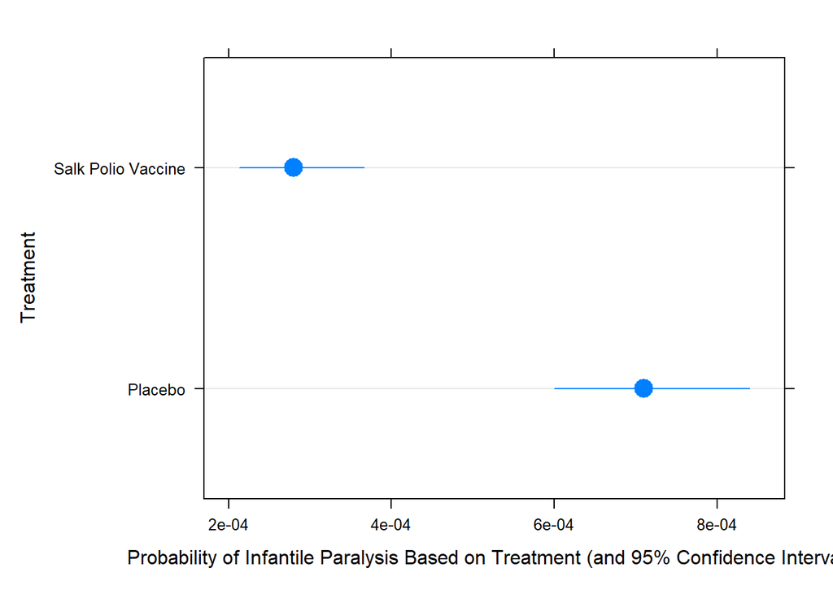

```r
#saving the estimates and CIs from the prop tests
pHat   <- c(0.00071, 0.0002798797)
lower95 <- c(0.0006001657, 0.0002133819)
upper95 <- c(0.0008394233, 0.0003662140)

polio_plot <- Cbind(pHat, lower95, upper95)

Treatment <- as.factor( c("Placebo", "Salk Polio Vaccine"))

#the plot
Dotplot(Treatment ~ polio_plot,
        xlab = "Probability of Infantile Paralysis Based on Treatment (and 95% Confidence Intervals)",
        ylab = "Treatment", ylim=c(.5,2.5), cex=2)
```

These results provide overwhelming evidence that the odds of infantile paralysis are lower for those who received the Salk vaccine (one-sided p-value < 0.0001). The odds of infantile paralysis are 2.54 times greater for the placebo treatment than the Salk vaccine (95% CI: 1.94 to $\infty$). Yes, the observed proportion in the control group is drastically larger than would be excepted under the null hypothesis (one-sided p-value < 0.0001).

**Basic 18.10** Superb work throughout. Chapter 18 hadn’t yet introduced the Fisher test, but the Fisher test odds ratio (two tailed) will give you an estimate for the upper CI that isn’t infinity **score 5/5**

## 19.23

```r
#Read-In the data
birds <- Sleuth3::ex1923

birds <- birds %>%
  mutate(expected_n = (N/9866)*414) %>%
  mutate(expected_n2 = (N/sum(N))*sum(n)) %>%  #just making sure the calculation given by the textbook is the same as that given by prof Gallagher; it is
  mutate(x = ((n-expected_n)^2)/expected_n)

#just sorting the expected values
birds %>%
  arrange(expected_n)
```

```
##                  Order    N   n   expected_n  expected_n2            x
## 1    Opisthodomiformes    1   0   0.04196229   0.04196229 4.196229e-02
## 2       Casuariiformes    4   2   0.16784918   0.16784918 1.999877e+01
## 3  Phoenicopteriformes    5   1   0.20981147   0.20981147 2.975995e+00
## 4          Coliiformes    6   1   0.25177377   0.25177377 2.223593e+00
## 5     Struthioniformes   10   5   0.41962295   0.41962295 4.999692e+01
## 6       Pterocliformes   16   3   0.67139672   0.67139672 8.076288e+00
## 7      Sphenisciformes   17   1   0.71335901   0.71335901 1.151777e-01
## 8     Podicipediformes   22   1   0.92317048   0.92317048 6.394024e-03
## 9      Musophagiformes   23   1   0.96513278   0.96513278 1.259643e-03
## 10       Trogoniformes   39   2   1.63652950   1.63652950 8.072620e-02
## 11        Tinamiformes   47  19   1.97222785   1.97222785 1.470140e+02
## 12       Galbuliformes   54   2   2.26596392   2.26596392 3.121709e-02
## 13      Pelecaniformes   65   6   2.72754916   2.72754916 3.926211e+00
## 14   Procellariiformes  108   5   4.53192783   4.53192783 4.834401e-02
## 15       Ciconiiformes  114  14   4.78370160   4.78370160 1.775616e+01
## 16    Caprimulgiformes  118   8   4.95155078   4.95155078 1.876794e+00
## 17        Anseriformes  150   5   6.29434421   6.29434421 2.661639e-01
## 18        Cuculiformes  159   3   6.67200487   6.67200487 2.020925e+00
## 19          Gruiformes  204  21   8.56030813   8.56030813 1.807715e+01
## 20        Strigiformes  209   2   8.77011960   8.77011960 5.226214e+00
## 21       Coraciiformes  213   8   8.93796878   8.93796878 9.843237e-02
## 22         Galliformes  281  24  11.79140482  11.79140482 1.264055e+01
## 23       Falconiformes  308  31  12.92438678  12.92438678 2.527995e+01
## 24       Columbiformes  309   2  12.96634908  12.96634908 9.274840e+00
## 25     Charadriiformes  343  62  14.39306710  14.39306710 1.574661e+02
## 26          Piciformes  344   2  14.43502939  14.43502939 1.071213e+01
## 27      Psittaciformes  353   1  14.81269005  14.81269005 1.288020e+01
## 28         Apodiformes  424   3  17.79201297  17.79201297 1.229786e+01
## 29       Passeriformes 5920 179 248.41678492 248.41678492 1.939760e+01
```

```r
#sum the expected values
chi2 <- sum(birds$x)

#calculating the p-value for the chi-squared statistic with 28df, using 1-pchisq to get the area to the right of the curve
1-pchisq(chi2, 28)
```

```
## [1] 0
```

This data provides overwhelming evidence that the selection of birds was not random (p-value < 0.00001). Thus, the selection of bird species is most likely based on the information that was available which could result in biased sampling and incorrect conclusions.

**Basic 19.23** Excellent work. You should never report a p value of 0 or 1. In my calcualtion of the chi2 it was pchisq(sum(birds$Chi2), df=28, lower.tail=FALSE), [1] 4.121023e-96 But, you can’t report that either since machine precision for 0 is only 2e-16. Just report p<1e-6 **score 5/5**

# Supplemental Problems

## 18.19

```r
#create the tables
arrests <- matrix(c(28, 35, 36, 20), nrow = 2, ncol = 2, byrow = TRUE,
                  dimnames = list(c("No Preschool", "Preschool"),c("No", "Yes")))

income <- matrix(c(38, 25, 22, 34), nrow = 2, ncol = 2, byrow = TRUE,
                  dimnames = list(c("No Preschool", "Preschool"),c("No", "Yes")))

#look at the tables
arrests
```

```
##              No Yes
## No Preschool 28  35
## Preschool    36  20
```

```r
income
```

```
##              No Yes
## No Preschool 38  25
## Preschool    22  34
```

```r
#run the fishers test for arrests
fisher.test(arrests)
```

```
##
##  Fisher's Exact Test for Count Data
##
## data:  arrests
## p-value = 0.04249
## alternative hypothesis: true odds ratio is not equal to 1
## 95 percent confidence interval:
##  0.1983322 0.9898925
## sample estimates:
## odds ratio
##  0.4475579
```

```r
#take the inverse of the odds ratio to interpret it
1/0.4475579
```

```
## [1] 2.234348
```

```r
#CIs
1/0.1983322
```

```
## [1] 5.042046
```

```r
1/0.9898925
```

```
## [1] 1.010211
```

```r
#run the fishers test for income
fisher.test(income)
```

```
##
##  Fisher's Exact Test for Count Data
##
## data:  income
## p-value = 0.02784
## alternative hypothesis: true odds ratio is not equal to 1
## 95 percent confidence interval:
##  1.056915 5.244105
## sample estimates:
## odds ratio
##   2.331782
```

```r
# PRESENTATION PLOT  for arrests
#just looking at the data matrix
arrests
```

```
##              No Yes
## No Preschool 28  35
## Preschool    36  20
```

```r
#proportion tests
prop.test(35, (35+28)) #Est = 0.5555556  ; CI = 0.4255300   to 0.6787945
```

```
##
##  1-sample proportions test with continuity correction
##
## data:  35 out of (35 out of 35 + 28
## X-squared = 0.57143, df = 1, p-value = 0.4497
## alternative hypothesis: true p is not equal to 0.5
## 95 percent confidence interval:
##  0.4255300 0.6787945
## sample estimates:
##         p
## 0.5555556
```

```r
prop.test(20, (20+36)) #Est = 0.3571429  ; CI = 0.2368611   to 0.4970247
```

```
##
##  1-sample proportions test with continuity correction
##
## data:  20 out of (20 out of 20 + 36
## X-squared = 4.0179, df = 1, p-value = 0.04502
## alternative hypothesis: true p is not equal to 0.5
## 95 percent confidence interval:
##  0.2368611 0.4970247
## sample estimates:
##         p
## 0.3571429
```

```r
#saving the estimates and CIs from the prop tests
pHat   <- c(0.5555556 , 0.3571429)
lower95 <- c(0.4255300 , 0.2368611)
upper95 <- c(0.6787945, 0.4970247)

arrests_plot <- Cbind(pHat, lower95, upper95)

#getting the matrix into the correct format
Treatment <- as.factor(c("No Preschool", "Preschool"))

#the plot
p1 <- Dotplot(Treatment ~ arrests_plot,
        xlab = "Probability of Getting Arrested 5 or More Times \n Based on Preschool Program (and 95% Confidence Intervals)",
        ylab = "Treatment", ylim=c(.5,2.5), cex=2)




# PRESENTATION PLOT  for income
#just looking at the data matrix
income
```

```
##              No Yes
## No Preschool 38  25
## Preschool    22  34
```

```r
#proportion tests
prop.test(25, (25+38)) #Est = 0.3968254   ; CI = 0.2782316   to 0.5280338
```

```
##
##  1-sample proportions test with continuity correction
##
## data:  25 out of (25 out of 25 + 38
## X-squared = 2.2857, df = 1, p-value = 0.1306
## alternative hypothesis: true p is not equal to 0.5
## 95 percent confidence interval:
##  0.2782316 0.5280338
## sample estimates:
##         p
## 0.3968254
```

```r
prop.test(34, (34+22)) #Est = 0.6071429   ; CI = 0.4675350    to 0.7320673
```

```
##
##  1-sample proportions test with continuity correction
##
## data:  34 out of (34 out of 34 + 22
## X-squared = 2.1607, df = 1, p-value = 0.1416
## alternative hypothesis: true p is not equal to 0.5
## 95 percent confidence interval:
##  0.4675350 0.7320673
## sample estimates:
##         p
## 0.6071429
```

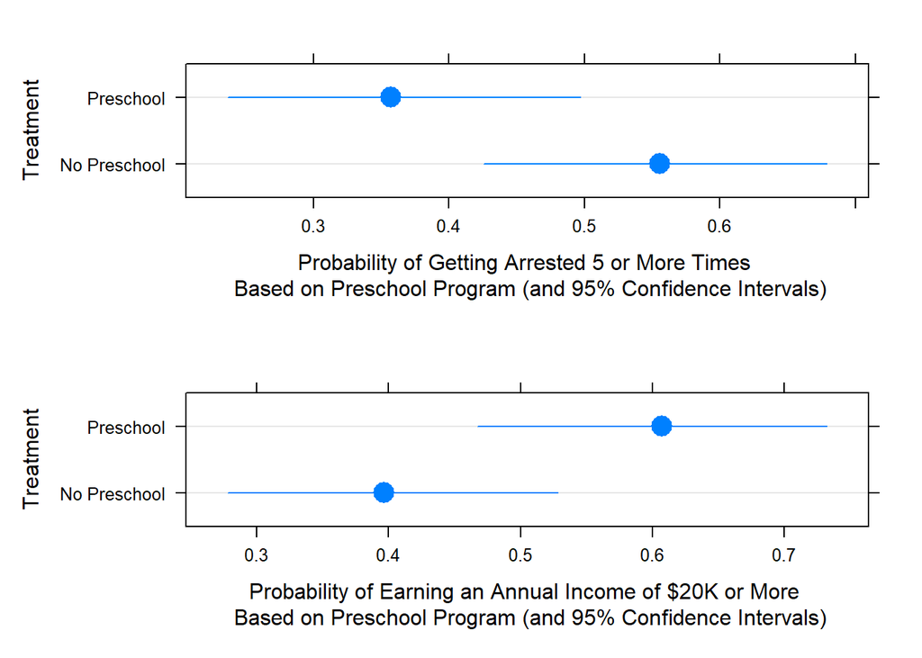

```r
#saving the estimates and CIs from the prop tests
pHat   <- c(0.3968254 , 0.6071429)
lower95 <- c(0.2782316 , 0.4675350)
upper95 <- c(0.5280338, 0.7320673)

arrests_plot2 <- Cbind(pHat, lower95, upper95)

#getting the matrix into the correct format
Treatment <- as.factor(c("No Preschool", "Preschool"))

#the plot
p2 <- Dotplot(Treatment ~ arrests_plot2,
        xlab = "Probability of Earning an Annual Income of $20K or More \n Based on Preschool Program (and 95% Confidence Intervals)",
        ylab = "Treatment", ylim=c(.5,2.5), cex=2)

grid.arrange(p1, p2, ncol = 1)
```

**Supplemental 18.19** Excellent analyses throughout and very nice graphics. **score 2.5/2.5**

## 19.20

```r
#create the table
diet <- matrix(c(1, 44, 49, 228), nrow = 2, ncol = 2, byrow = TRUE,
                  dimnames = list(c("Women", "Men"),c("Dropped Out", "Completed")))

#look at the table
diet
```

```
##       Dropped Out Completed
## Women           1        44
## Men            49       228
```

```r
#run the fishers test
fisher.test(diet)
```

```
##
##  Fisher's Exact Test for Count Data
##
## data:  diet
## p-value = 0.006332
## alternative hypothesis: true odds ratio is not equal to 1
## 95 percent confidence interval:
##  0.002571065 0.656355519
## sample estimates:
## odds ratio
##  0.1061466
```

```r
#to get the odds ratio interpretative
1/0.1061466
```

```
## [1] 9.420933
```

```r
#and the CIs
1/0.002571065
```

```
## [1] 388.9439
```

```r
1/0.656355519
```

```
## [1] 1.523565
```

```r
# PRESENTATION PLOT
#just looking at the data matrix
diet
```

```
##       Dropped Out Completed
## Women           1        44
## Men            49       228
```

```r
#proportion tests
prop.test(1, (1+44)) #Est = 0.02222222 ; CI = 0.001161097  to 0.132339248
```

```
##
##  1-sample proportions test with continuity correction
##
## data:  1 out of (1 out of 1 + 44
## X-squared = 39.2, df = 1, p-value = 3.825e-10
## alternative hypothesis: true p is not equal to 0.5
## 95 percent confidence interval:
##  0.001161097 0.132339248
## sample estimates:
##          p
## 0.02222222
```

```r
prop.test(49, (49+228)) #Est = 0.1768953 ; CI = 0.1348649  to 0.2281157
```

```
##
##  1-sample proportions test with continuity correction
##
## data:  49 out of (49 out of 49 + 228
## X-squared = 114.38, df = 1, p-value < 2.2e-16
## alternative hypothesis: true p is not equal to 0.5
## 95 percent confidence interval:
##  0.1348649 0.2281157
## sample estimates:
##         p
## 0.1768953
```

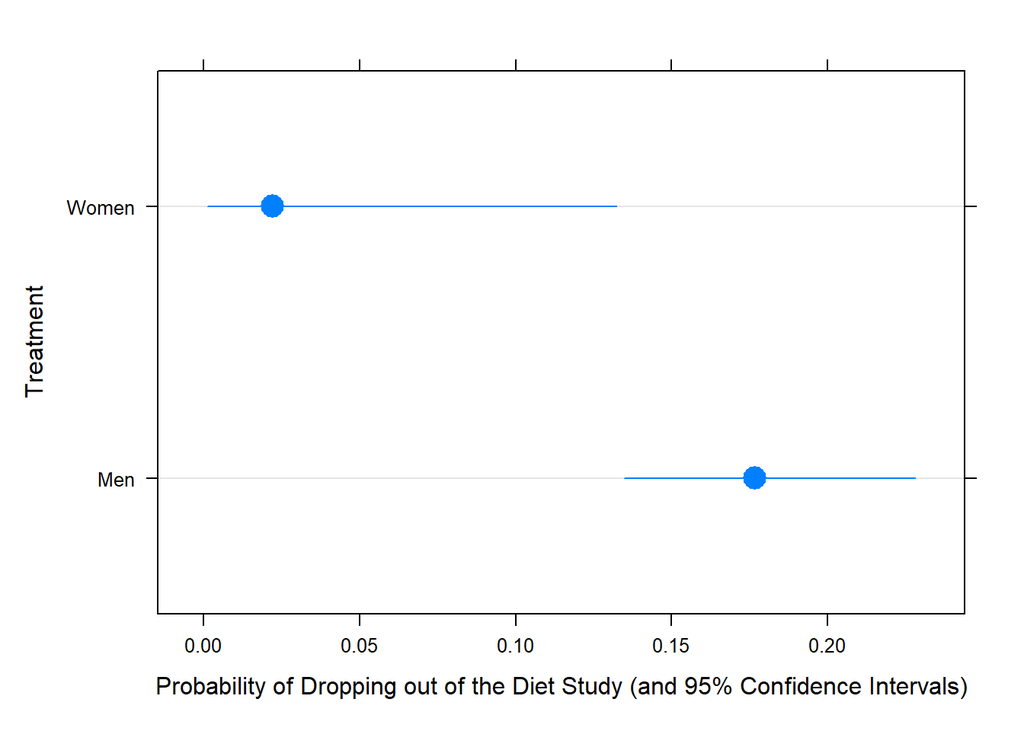

```r
#saving the estimates and CIs from the prop tests
pHat   <- c(0.02222222 , 0.1768953)
lower95 <- c(0.001161097 , 0.1348649 )
upper95 <- c(0.132339248, 0.2281157)

diet_plot <- Cbind(pHat, lower95, upper95)

Gender <- as.factor( c("Women", "Men"))

#the plot
Dotplot(Gender ~ diet_plot,
        xlab = "Probability of Dropping out of the Diet Study (and 95% Confidence Intervals)",
        ylab = "Treatment", ylim=c(.5,2.5), cex=2)
```

**Supplemental 19.20 I** Excellent throughout. You can get the odds ratios greater than 1 by just flipping a single row or column (not both) as shown in the following code chunk **Score 2.5/2.5**

```r
myTable3 <- matrix(c(44,45-44,277-49,49), nrow = 2, ncol = 2, byrow = TRUE,
                   dimnames = list(c("Women", "Men"),
                                   c("Stayed", "Dropped")))
myTable3
```

```
##       Stayed Dropped
## Women     44       1
## Men      228      49
```

```r
fisher.test(myTable3)
```

```
##
##  Fisher's Exact Test for Count Data
##
## data:  myTable3
## p-value = 0.006332
## alternative hypothesis: true odds ratio is not equal to 1
## 95 percent confidence interval:
##    1.523565 388.943846
## sample estimates:
## odds ratio
##   9.420933
```

```r
fisher.test(myTable3, alternative="greater")
```

```
##
##  Fisher's Exact Test for Count Data
##
## data:  myTable3
## p-value = 0.002917
## alternative hypothesis: true odds ratio is greater than 1
## 95 percent confidence interval:
##  1.822827      Inf
## sample estimates:
## odds ratio
##   9.420933
```